# practice_assignment

13 January, 2020

## Data inspection with R (2pt)

In this question we use dataset `Titanic`. This data set provides information on the fate of passengers on the fatal maiden voyage of the ocean liner ‘Titanic’, summarized according to economic status (class), sex, age and survival.

A 4-dimensional array resulting from cross-tabulating 2201 observations on 4 variables. The variables and their levels are as follows:

| No | Name | Levels |
| --- | --- | --- |
| 1 | Class | 1st, 2nd, 3rd, Crew |
| 2 | Sex | Male, Female |
| 3 | Age | Child, Adult |
| 4 | Survived | No, Yes |

### Passenger breakdown

```r
dat <- data.frame(Titanic)
table(dat$Age) %>%  knitr::kable()
```

| Var1 | Freq |
| --- | --- |
| Child | 16 |
| Adult | 16 |

```r
table(dat$Sex) %>%  knitr::kable()
```

| Var1 | Freq |
| --- | --- |
| Male | 16 |
| Female | 16 |

### Survival

Survival rate is the percentage of people in a group still alive; therefore the survial rate here could be expressed as:
$$\text{survial rate} = \frac{\text{number of passengers who survive}}{\text{total number of passengers on the Titanic}}$$

```r
survival_rate <- function(data){
  total <- sum(data$Freq)
  survived <- sum(data[data$Survived == "Yes",]$Freq)
  rate <- sum(data[data$Survived == "Yes",]$Freq)/sum(data$Freq)
  return(c(total, survived, rate))
}
```

```r
children <- dat[dat$Age == "Child",]
adults <- dat[dat$Age == "Adult",]
survival_rate(children)
survival_rate(adults)
```

[output not shown]

```r
first <- dat[dat$Class == "1st",]
second <- dat[dat$Class == "2nd",]
thrid <- dat[dat$Class == "3rd",]
crew <- dat[dat$Class == "Crew",]
survival_rate(first)
survival_rate(second)
survival_rate(thrid)
survival_rate(crew)
```

The survial rates among different classes are:

- The total number of passenger in 1st class on the ship were 325 , and there were 203 survived. The survival rate is $62\%$.
- The total number of passenger in 2nd class are 285 , and there were 118 survived. The survival rate is $41\%$.
- The total number of passenger in 3rd class on the ship were 706 , and there were only 178 survived. The survival rate is $25\%$.
- The total number of passenger in crew are 885 , and there were 212 survived. The survival rate is $24\%$.

## Data visualization (1.5pt)

We analysis the dataset about the effect of Vitamin C on tooth growth in guinea pigs. The response is the *length of odontoblasts (cells responsible for tooth growth)* in 60 guinea pigs. Each animal received one of three dose levels of vitamin C (0.5, 1, and 2 mg/day) by one of two delivery methods, orange juice or ascorbic acid (a form of vitamin C and coded as VC).

```r
dat2 <- read.table("guinea_pigs_tooth_growth.txt", header = T)
```

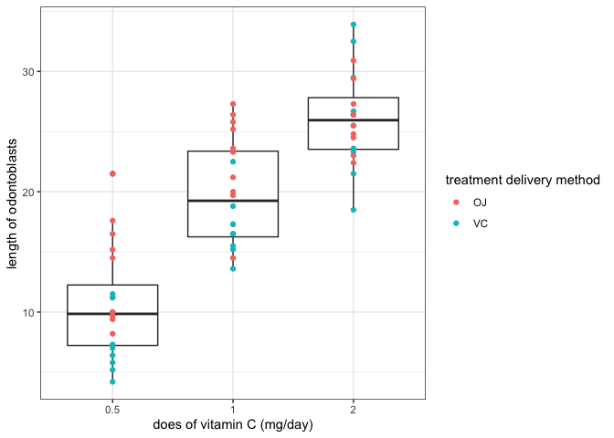

```r
dat2 %>%
  ggplot()+
  geom_boxplot(aes(x = factor(dat2$dose), y = dat2$len)) +
  geom_point(aes(x = factor(dat2$dose), y = dat2$len, color = factor(dat2$supp))) +
  xlab("does of vitamin C (mg/day)") +
  ylab("length of odontoblasts") +
  scale_color_discrete(name="treatment delivery method") +
  theme_bw()
```

The data frame has 60 observations on 3 variables. To analysis the effect of 3 different treatment (does level of the Vitamin C) on the length of the odontoblasts, we compare 3 does levels. Two types of treatment delivery method are blocking variables.

We use boxplot to compare 3 does levels, and we find as the does amont increases the lenth of odontoblasts also increases, which means the does levels might has significant effect on the tooth growth. Moreover, two colours identify levels of the blocking variable. We find that the orange juice method yeilds higher length than ascorbic acid. Thus, the difference between two blocking levels might also be significant.